# Statistics

Torina Lewis

7/23/2019

To apply some of the knowledge that was learned from data camp, We use my clean data set from the data wrangling report and call it dta_stats. The code below ingests the data.

```r
dta_stats <- read.csv("dta.csv")
```

Now, the libraries that are necessary to show the skills learned are loaded into are loaded.

```r
library(tidyverse)
library(haven)
library(sjmisc)
library(plyr)
```

```r
library(dplyr)
library(ggplot2)
library(caret)
library(markdown)
```

Here, we create a box plot for the standard and raw scores.

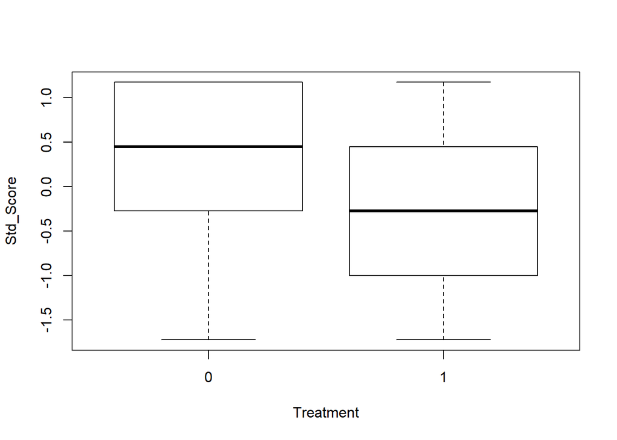

```r
boxplot(Std_Score~Treatment, data = dta_stats)
```

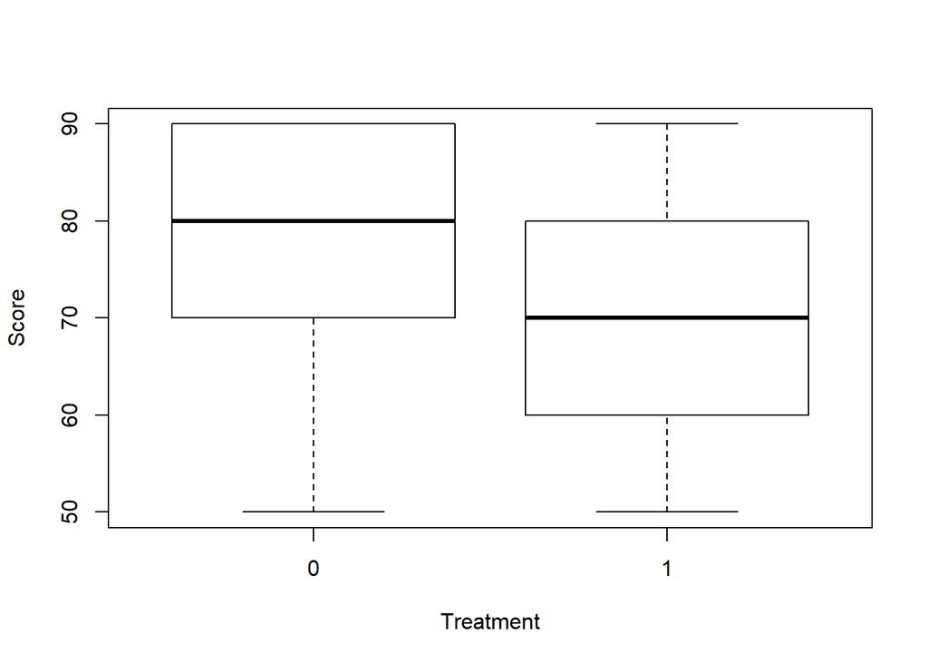

```r
boxplot(Score~Treatment, data = dta_stats)
```

Scatter plots are good tools to observe the relationships between variables. This plot shows the particular grade earned by major. The data is also divded by treatment and control groups.

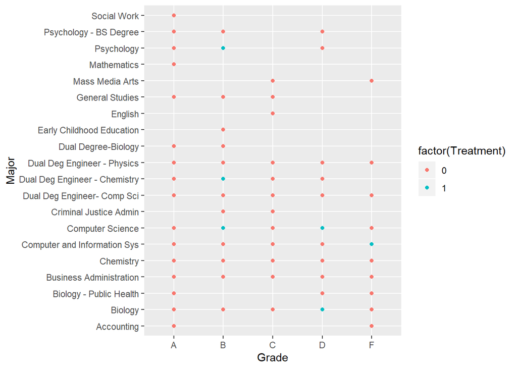

```r
ggplot(dta_stats, aes(x = Grade, y = Major, color=factor(Treatment))) +
  geom_point()
```

Here is a table of the number of students that earned a particular grade is displayed.

```r
table(dta_stats$Grade)
```

```
##
##  A  B  C  D  F
## 87 90 69 34 52
```

The histogram determines the major that takes the course more frequently. It also determines the breakdown of grades by major.

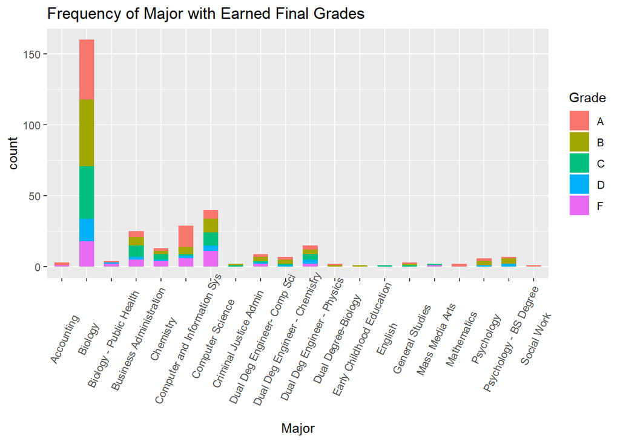

```r
dta_hist <- ggplot(dta_stats, aes(Major))
dta_hist + geom_bar(aes(fill=Grade), width = 0.6) +
  theme(axis.text.x = element_text(angle=65, vjust=0.6)) +
  labs(title="Frequency of Major with Earned Final Grades")
```

It is imperative that we retrieve information for the treatment and control groups separately. Thus the means for these groups are calculated for the outcome variable. We also determine the number of students in each group. The treatement group is labelled as 1 and the control group is labelled as 0.

```r
dta_stats %>%
  dplyr::group_by(Treatment) %>%
  dplyr::summarise(n_students = n(),
            mean_Score = mean(Score),
            std_error = sd(Score) / sqrt(n_students))
```

```
## # A tibble: 2 x 4
##   Treatment n_students mean_Score std_error
##       <int>      <int>      <dbl>     <dbl>
## 1         0        305       74.2     0.797
## 2         1         27       68.9     2.29
```

We run the same code but this time we use the standard score. The standard score is the standard z-score.

```r
dta_stats %>%
  dplyr:: group_by(Treatment) %>%
  dplyr:: summarise(n_students = n(),
            mean_Std_Score = mean(Std_Score),
            std_error = sd(Std_Score) / sqrt(n_students))
```

```
## # A tibble: 2 x 4
##   Treatment n_students mean_Std_Score std_error
##       <int>      <int>          <dbl>     <dbl>
## 1         0        305         0.0314    0.0576
## 2         1         27        -0.355     0.165
```

The mean of the entire popoulation without grouping may also be useful and is calculated.

```r
mean(dta_stats$Score)
```

```
## [1] 73.79518
```

Looking at the plots that I have created, it appears that I will need to filter the data becasue some majors have extremely small numbers. Also, I will use a t-test to compare the means of the control and treatment groups to determine if their is a difference in the means. This information shows that the number of matheamtics majors are dismal. Thus as a mathematics professor, it seems that something should be done to increase this number.